# Differential analysis and GSEA

Miguel Ramón Alonso

2023-04-01

## DeSEQ2

This is an R Markdown document which contains a fully working script for differential analysis of different biological samples. Main objective is to be able to perform the differential analysis both through DeSEQ2 and the other tool whose name I can’t remember.

### Pregunta 4 (3 puntos):

What genes are differentially expressed between the samples belonging to the group treated with OHT compared to the control after 24 hours? And in the case of samples treated with DPN, also after 24 hours? As part of the answer to this question, you can provide one or more attached tables including the differentially expressed genes, indicating the criteria used to filter the results, as well as any other graphs that have been generated during the analysis.

```r
# Open both tables as TSV files with header and set a fixed seed for replicacy
set.seed(1998)
cts <- read.table("data/input-2/rawcounts.tsv", sep = "\t", header = TRUE, row.names = 1)
metadata <- read.table("data/input-2/metadata.tsv", sep = "\t", header = TRUE, row.names = 1)

# Factorization of the parameters to overcome possible warnings and/or memory glitches
metadata$agent <- factor(metadata$agent)
metadata$patient <- factor(metadata$patient)
metadata$time <- factor(metadata$time)

# Now we'll make a new column containing a concatenation of agent and time, for resolution of #1
metadata$agent_time <- as.factor(paste(metadata$agent, metadata$time, sep="_"))

# And check if everything worked out
head(metadata)
```

```
##           patient   agent time  agent_time
## GSM913873       1 Control  24h Control_24h
## GSM913874       1 Control  48h Control_48h
## GSM913875       1     DPN  24h     DPN_24h
## GSM913876       1     DPN  48h     DPN_48h
## GSM913877       1     OHT  24h     OHT_24h
## GSM913878       1     OHT  48h     OHT_48h
```

```r
all(rownames(metadata) == colnames(cts))
```

```
## [1] TRUE
```

```r
all(rownames(metadata) %in% colnames(cts))
```

```
## [1] TRUE
```

In order to solve the first question in this second part of the exercise, first creating a subset for 24h and 48h samples, and then using this subset to pick only those counts which coincide.

```r
# DeSEQ2 object creation
## Design is set to combine drug and time so we can make the experiment appropriately.
dds <- DESeqDataSetFromMatrix(countData = cts,
                                       colData = metadata,
                                       design =~ patient + agent_time)
# Check
dds
```

```
## class: DESeqDataSet
## dim: 53160 24
## metadata(1): version
## assays(1): counts
## rownames(53160): ENSG00000000003 ENSG00000000005 ... ENSG00000257111
##   ENSG00000257112
## rowData names(0):
## colnames(24): GSM913873 GSM913874 ... GSM913895 GSM913896
## colData names(4): patient agent time agent_time
```

```r
summary(dds)
```

```
## [1] "DESeqDataSet object of length 53160 with 0 metadata columns"
```

Pre-processing of the counts is also recommended to remove those reads with too little counts to be considered relevant. To keep consistency with how the sample experiment was performed in class with ‘airway’ package, we will keep the quality threshold to > 10 counts.

```r
# Subsample genes with more than 10 counts
keep <- rowSums(counts(dds)) >= 10
dds <- dds[keep, ]
summary(dds)
```

```
## [1] "DESeqDataSet object of length 24416 with 0 metadata columns"
```

If we continue to follow the logic of the sample pipeline from class, a VST assay should be performed for data exploration. In my opinion, previous sub-setting of the data kind of defeats the purpose, as it is going to definitely affect data normalization and will produce biased statistics. Again, a way to overcome this problem should be approached. Then, we’ll perform a distance assay between the count matrix and the variant-stabilized object.

```r
# VST object creation
vsd <- vst(dds, blind = TRUE)
```

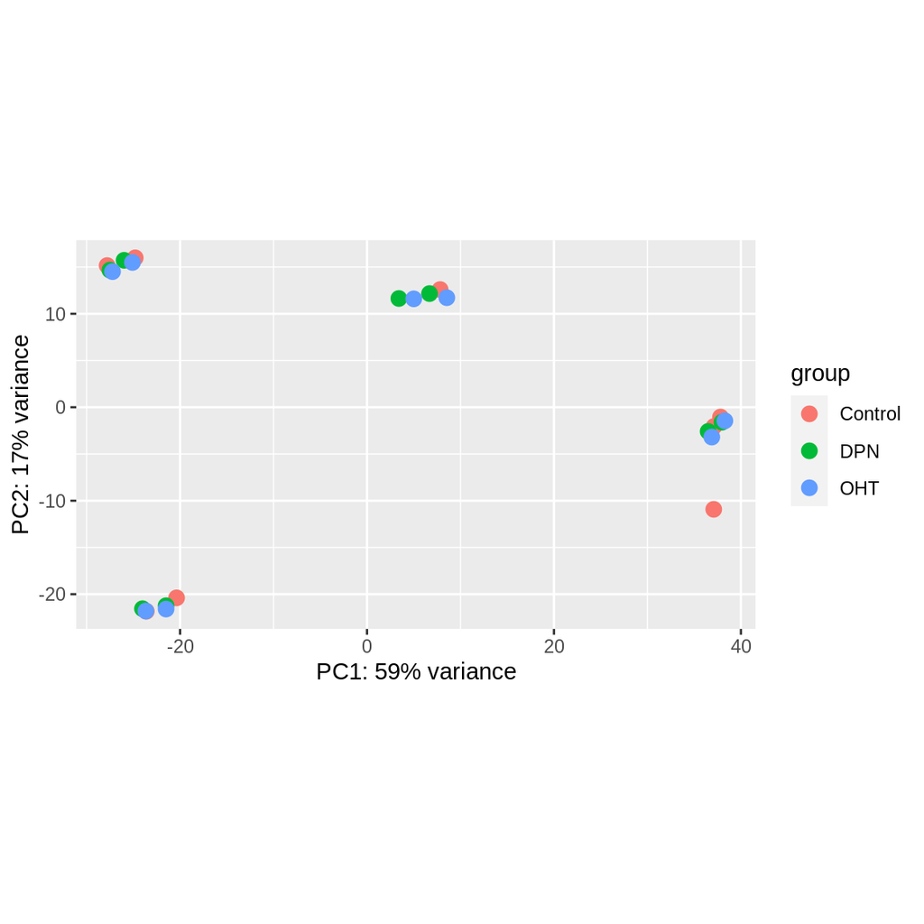

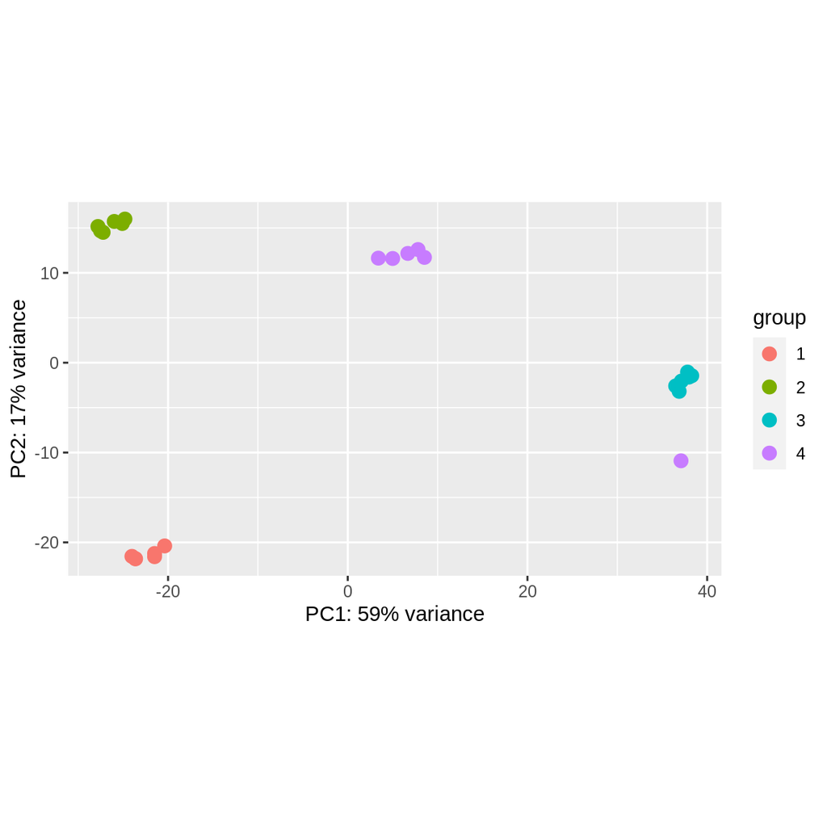

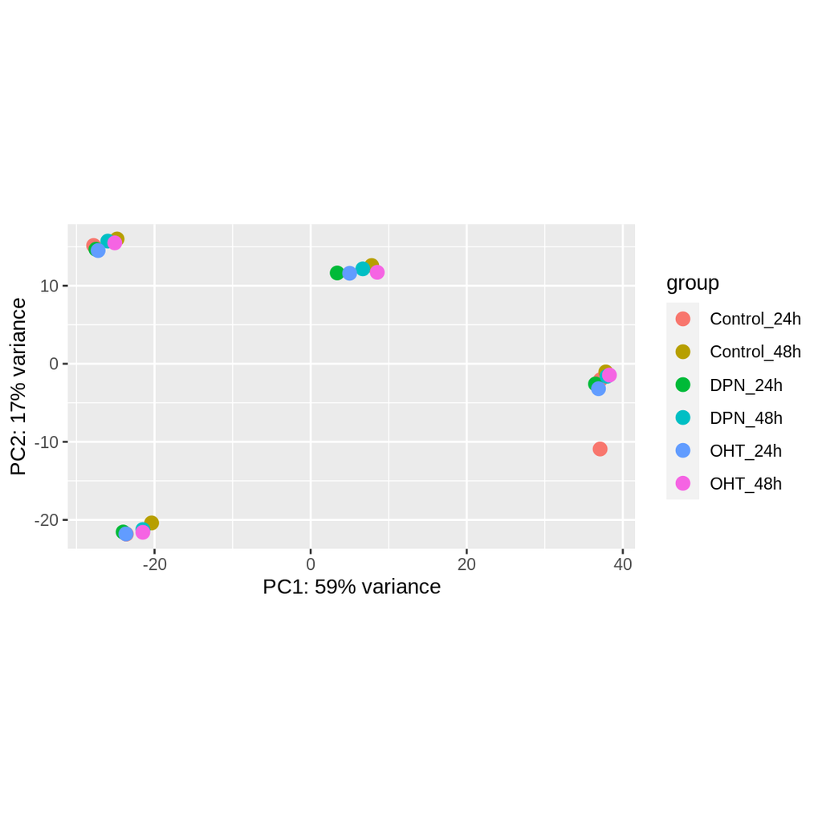

Distance calculation

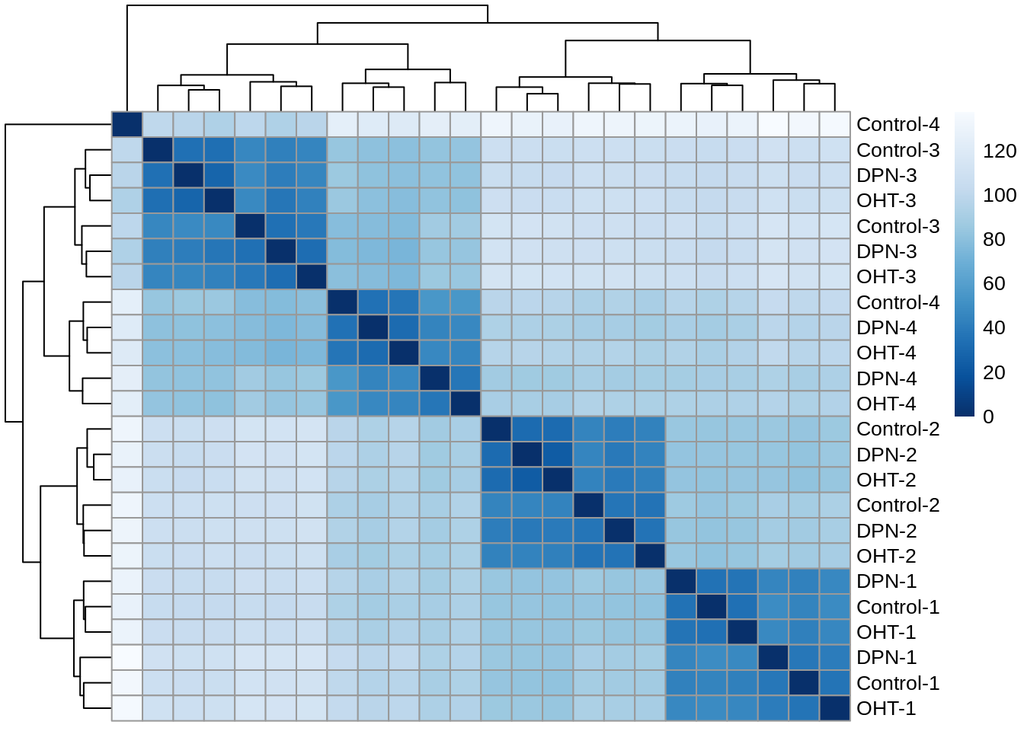

```r
# Distance calculation
sampleDists <- dist(t(assay(vsd)))

sampleDistMatrix <- as.matrix(sampleDists)
rownames(sampleDistMatrix) <- paste(vsd$agent, vsd$patient, sep="-")
colnames(sampleDistMatrix) <- NULL
colors <- colorRampPalette( rev(brewer.pal(9, "Blues")) )(255)
pheatmap(sampleDistMatrix,
         clustering_distance_rows=sampleDists,
         clustering_distance_cols=sampleDists,
         col=colors)
```

After plotting PCA and Distance matrix, an obvious outlier shows up in group 4. Given that we are only going to work with 24h samples in this first part of the analysis, we can remove those from the object. Note that the removal of this outliers depends vastly on how the experiment was performed, in what we are looking to achieve, and the investigator.

```r
# Now, here we remove completely group 4 due to the outlier. A different assay was performed removing only 24h/Group 4 patients, but results only varied marginally. The outlier was not solely removed as it wouldn't make biological sense.
metadata = subset(metadata, patient != 4)


# Next we remove those rows with no concordance with metadata
cts <- cts[, rownames(metadata)]

# Check if it worked out
all(rownames(metadata) == colnames(cts))
```

```
## [1] TRUE
```

```r
all(rownames(metadata) %in% colnames(cts))
```

```
## [1] TRUE
```

```r
# And remake our DESeq2 object with our new data
dds <- DESeqDataSetFromMatrix(countData = cts,
                                       colData = metadata,
                                       design =~ patient + agent_time)
```

```
## factor levels were dropped which had no samples
```

```r
dds
```

```
## class: DESeqDataSet
## dim: 53160 18
## metadata(1): version
## assays(1): counts
## rownames(53160): ENSG00000000003 ENSG00000000005 ... ENSG00000257111
##   ENSG00000257112
## rowData names(0):
## colnames(18): GSM913873 GSM913874 ... GSM913889 GSM913890
## colData names(4): patient agent time agent_time
```

```r
summary(dds)
```

```
## [1] "DESeqDataSet object of length 53160 with 0 metadata columns"
```

```r
keep <- rowSums(counts(dds)) >= 10
dds <- dds[keep, ]
summary(dds)
```

```
## [1] "DESeqDataSet object of length 22491 with 0 metadata columns"
```

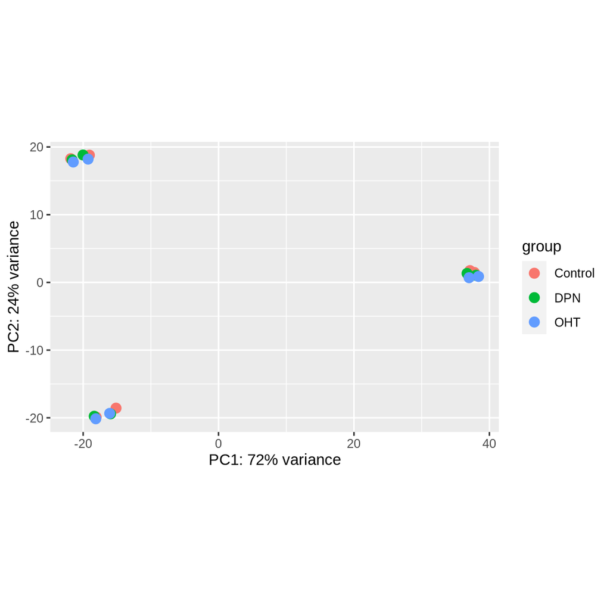

```r
vsd <- vst(dds, blind = TRUE)

plotPCA(vsd, intgroup = "agent")
```

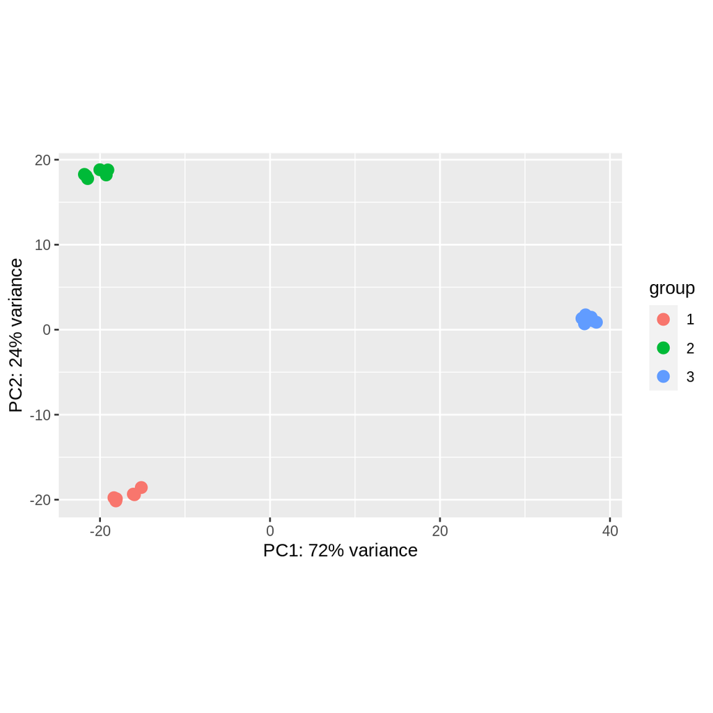

```r
plotPCA(vsd, intgroup = "patient")
```

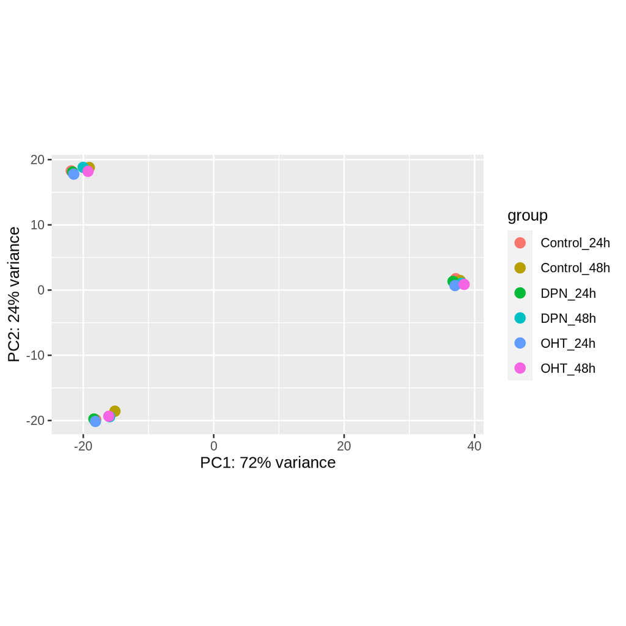

```r
plotPCA(vsd, intgroup = "agent_time")
```

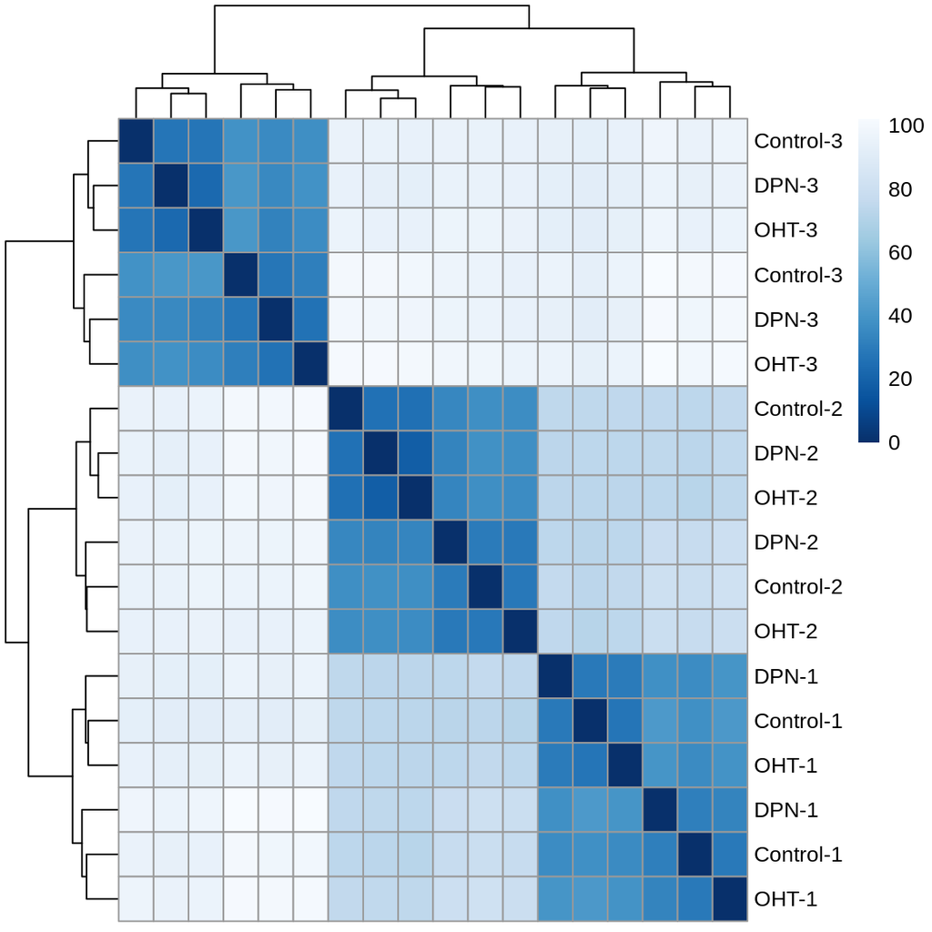

```r
sampleDists <- dist(t(assay(vsd)))

sampleDistMatrix <- as.matrix(sampleDists)
rownames(sampleDistMatrix) <- paste(vsd$agent, vsd$patient, sep="-")
colnames(sampleDistMatrix) <- NULL
colors <- colorRampPalette( rev(brewer.pal(9, "Blues")) )(255)
pheatmap(sampleDistMatrix,
         clustering_distance_rows=sampleDists,
         clustering_distance_cols=sampleDists,
         col=colors)
```

DESeq2

```r
# DESeq2 experiment
dds2 <- DESeq(dds, test = "Wald")
```

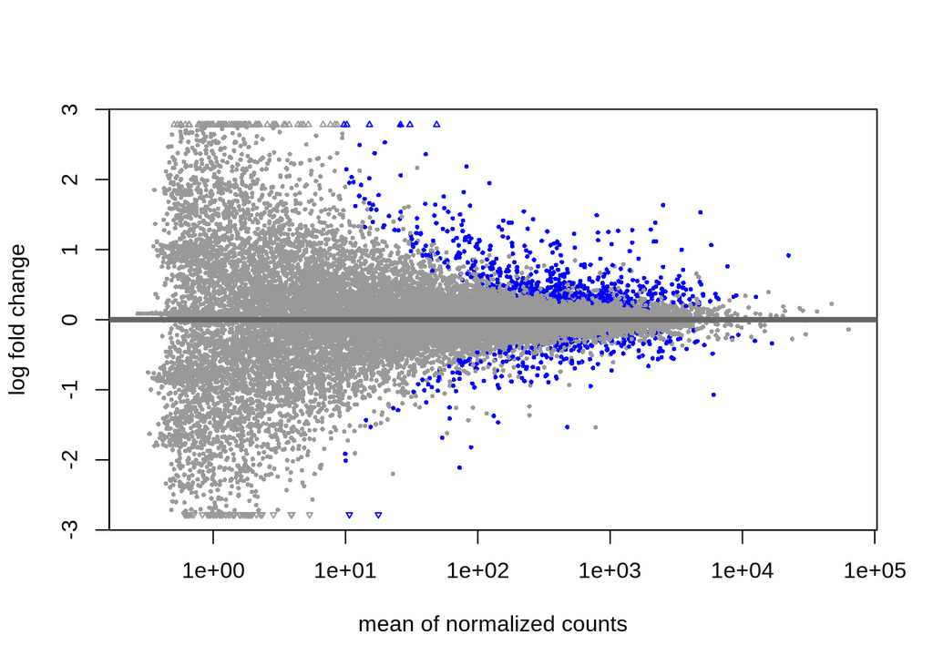

```r
plotMA(dds2)
```

Gene listing for OHT (with no log-fold threshold)

```r
results_OHT <- results(object = dds2,
                      contrast = c("agent_time", "Control_24h", "OHT_24h"),
                      alpha = 0.05, # predisponer NUESTRO ERROR, por defecto tiene un 0.1
                      pAdjustMethod = "BH",
                      tidy = TRUE
                      )
mat <- assay(vsd)[head(order(results_OHT$padj), 30), ]
pheatmap(mat)
```

[output not shown]

Gene listing for OHT (with log-fold threshold = 1)

```r
results_thresholded_OHT <- results(object = dds2,
                      contrast = c("agent_time", "Control_24h", "OHT_24h"),
                      lfcThreshold = 1,
                      alpha = 0.05,
                      pAdjustMethod = "BH",
                      tidy = TRUE
                      )
mat <- assay(vsd)[head(order(results_thresholded_OHT$padj), 30), ]
pheatmap(mat)
```

[output not shown]

Gene listing for DPN (with no log-fold threshold)

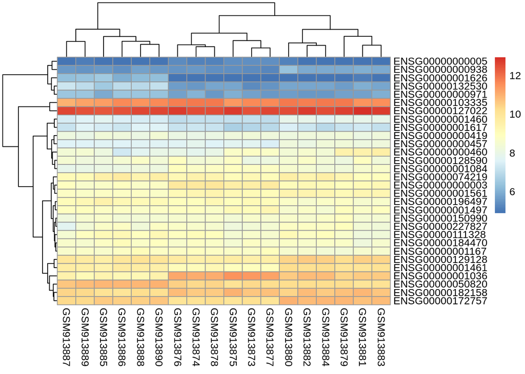

```r
results_DPN <- results(object = dds2,
                      contrast = c("agent_time", "Control_24h", "DPN_24h"),
                      alpha = 0.05,
                      pAdjustMethod = "BH",
                      tidy = TRUE
                      )
mat <- assay(vsd)[head(order(results_DPN$padj), 30), ]
pheatmap(mat)
```

Gene listing for DPN (with log-fold threshold = 1)

```r
results_thresholded_DPN <- results(object = dds2,
                      contrast = c("agent_time", "Control_24h", "DPN_24h"),
                      lfcThreshold = 1,
                      alpha = 0.05,
                      pAdjustMethod = "BH",
                      tidy = TRUE
                      )
mat <- assay(vsd)[head(order(results_thresholded_DPN$padj), 30), ]
pheatmap(mat)
```

[output not shown]

### DGE RESULTS AT 24H

```
## [1] "No. of representative genes for DPN treatment: 1"
```

```
## [1] "No. of representative genes for OHT treatment: 0"
```

```
## [1] "No. of representative genes for DPN treatment (threshold = 1): 0"
```

```
## [1] "No. of representative genes for OHT treatment (threshold = 1): 0"
```

### Pregunta 5 (2.5 puntos):

Our collaborator has compared the samples treated with DPN after 48 hours with the control samples. He has called us to report that the expression changes after 48 hours are much more evident, and we wonder if DPN produces any effect in the first 24 hours. To answer this question, we ask him to generate a GMT (input) file with the most expressed genes in the treated samples after 48 hours (DPN_perturbed) and the most expressed genes in the control sample (DPN_unperturbed). Perform a GSEA analysis to determine the effect of treatment at 24 hours. What conclusion do you reach? Include a table with the results of the analysis, highlighting the columns with the values used to extract your conclusions. Also include characteristic graphs of this type of analysis.

```r
# Create ranked object

# This is not efficient to do, but the object we created before for visualization is not the most comfortable to use for GSEA
results_DPN_gsea <- results(object = dds2,
                      contrast = c("agent_time", "Control_24h", "DPN_24h"),
                      alpha = 0.05
                      )

summary(results_DPN_gsea)
```

```
##
## out of 22491 with nonzero total read count
## adjusted p-value < 0.05
## LFC > 0 (up)       : 0, 0%
## LFC < 0 (down)     : 1, 0.0044%
## outliers [1]       : 0, 0%
## low counts [2]     : 0, 0%
## (mean count < 0)
## [1] see 'cooksCutoff' argument of ?results
## [2] see 'independentFiltering' argument of ?results
```

```r
head(rownames(results_DPN_gsea))
```

```
## [1] "ENSG00000000003" "ENSG00000000005" "ENSG00000000419" "ENSG00000000457"
## [5] "ENSG00000000460" "ENSG00000000938"
```

```r
# Make object with named columns
rnk_dpn <- data.frame(Feature = rownames(results_DPN_gsea), Stat = results_DPN_gsea$stat)

# Write table to file
rnk_file <- "data/input-2/ranked_DPN.rnk"
write.table(rnk_dpn, rnk_file, sep = "\t", quote = FALSE,
  col.names = FALSE, row.names = FALSE)
```

# NOTE THAT THIS REPORT MAY BE FOUND UNDER SCRIPTS DIRECTORY WHEN CREATED